# Analysis of Sediment Toxicity Data : Pesticides

# Install Libraries

```r
library(readxl)
library(tidyverse)
library(GGally)
library(maxLik)
```

# Load Basic Data

```r
sibfldnm <- 'Derived Data'
parent <- dirname(getwd())
sibling <- paste(parent,sibfldnm, sep = '/')
fn <- 'working.data.xls'

the.data <- read_excel(paste(sibling,fn, sep='/'),
    sheet = "Combined", col_types = c("skip",
        "text", "skip", "skip", "skip",
        "skip", "skip", "skip", "skip",
        "text", "text", "numeric", "text",
        "numeric", "text", "numeric", "numeric",
        "text", "text", "text", "skip",
        "skip", "skip", "skip", "skip",
        "numeric", "numeric", "skip", "skip",
        "skip", "skip", "skip", "skip",
        "skip")) %>%
  mutate(SAMPLE_ID = factor(SAMPLE_ID, levels = c("CSP-1", "CSP-2", "CSP-3", "CSP-4", "CSP-5", "CSP-6",
                                                  "CSP-7", "CSP-7D", "CSP-8", "CSP-9", "CSP-10", "CSP-11",
                                                  "CSP-12", "CSS-13", "CSP-14", "CSS-15")))
```

# Chemical Parameters

Pesticide Anylates are listed in a separate tab in the original Excel spreadsheet. Here we pull them into a vector, for later use.

```r
tmp<- read_excel(paste(sibling,fn, sep='/'), sheet = "Pesticides", skip = 3)
```

[output not shown]

```r
Pesticides.names <- tmp %>%
  select(1) %>%
  slice(1:19) %>%
 pull(PARAMETER_NAME)
  #mutate(PARAMETER_NAME = substr(PARAMETER_NAME, 1, nchar(PARAMETER_NAME)-7))
Pesticides.names
```

[output not shown]

```r
rm(tmp)
```

# Extract Pesticides Data

We filter down to selected parameters defined by a list of parameters. Notice the second and third filters, which samples out QA/QC samples. We have some duplicate samples (for CSP-6, CSP-15 - all measurements - CSP-10 - TOC data only - and CSP-9 - all observations EXCEPT TOC), so we calculate average values across multiple samples.

The following reads in data and assigns the value of the reporting limit to data that was below the detection limits. This sets us up for later analysis based on different assumptions about how to habdle the non-detects.

```r
Pesticides.data.long <- the.data %>%
  filter (the.data$PARAMETER_NAME %in% Pesticides.names) %>%
  filter(is.na(`%_RECOVERY`)) %>%
  filter(SAMPLE_ID != 'QC') %>%
  mutate(CONCENTRATION = ifelse(is.na(CONCENTRATION) & LAB_QUALIFIER == 'U', REPORTING_LIMIT, CONCENTRATION)) %>%
  group_by(SAMPLE_ID, PARAMETER_NAME) %>%
  summarize(CONCENTRATION = mean(CONCENTRATION, na.rm=TRUE),
            censored = sum(LAB_QUALIFIER=='U', na.rm=TRUE)) %>%
  ungroup()
```

# Frequency of Detects by Parameter

```r
Pesticides.data.long %>%
  group_by(PARAMETER_NAME) %>%
  summarize(n = n(),
            detects = sum(censored==0),
            nondetects = sum(censored>0))
```

| PARAMETER_NAME | n | detects | nondetects |
| --- | --- | --- | --- |
| 4,4'-DDD | 16 | 12 | 4 |
| 4,4'-DDE | 16 | 11 | 5 |
| 4,4'-DDT | 16 | 10 | 6 |
| ALDRIN | 16 | 0 | 16 |
| CIS-CHLORDANE | 16 | 7 | 9 |
| CIS-NONACHLOR | 16 | 0 | 16 |
| DIELDRIN | 16 | 0 | 16 |
| ENDOSULFAN I | 16 | 0 | 16 |
| ENDOSULFAN II | 16 | 0 | 16 |
| ENDRIN | 16 | 0 | 16 |

[output cut: 9 more lines]

```r
Pesticides.data <- Pesticides.data.long %>%
  select(-censored) %>%
  filter(PARAMETER_NAME %in% c("4,4'-DDD", "4,4'-DDE", "4,4'-DDT",
                               "CIS-CHLORDANE", "TRANS-NONACHLOR")) %>%
  spread(key = PARAMETER_NAME, value = CONCENTRATION) %>%
  rowwise() %>%
  mutate(totPesticides = sum(c(`4,4'-DDD`, `4,4'-DDE`, `4,4'-DDT`,
                               `CIS-CHLORDANE`, `TRANS-NONACHLOR`), na.rm = TRUE))
```

# Inital Pairs Plot

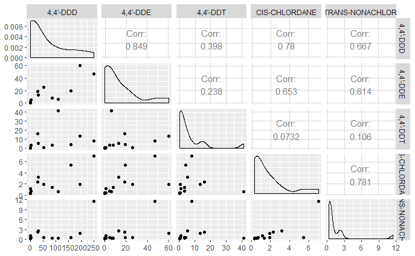

```r
ggpairs(Pesticides.data[2:6])
```

Highly skewed data, with some moderate correlations evident, but partially obscured by the liineart scale. Correlations are likely to be more evident in a log-log plot, or using rank correlations.

# A Check for Reasonableness

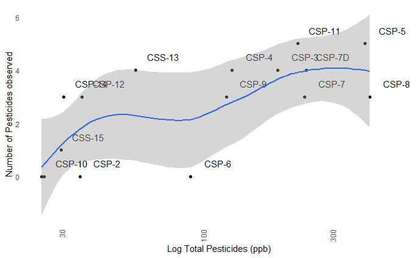

```r
tmp <- Pesticides.data.long %>%
  group_by(SAMPLE_ID) %>%
  summarize(totPesticides = sum(CONCENTRATION, na.rm = TRUE),
            countPesticides = sum(censored==0, na.rm=TRUE))

plt <- ggplot(tmp, aes(totPesticides, countPesticides)) +
  geom_point() +
  geom_text(aes(label = SAMPLE_ID),nudge_y = .5, nudge_x = .1) +
  geom_smooth() +
  scale_x_log10() +
  xlab('Log Total Pesticides (ppb)') +
  ylab('Number of Pesticides observed') +
  theme_minimal() +
plt
```

# Initial graphics

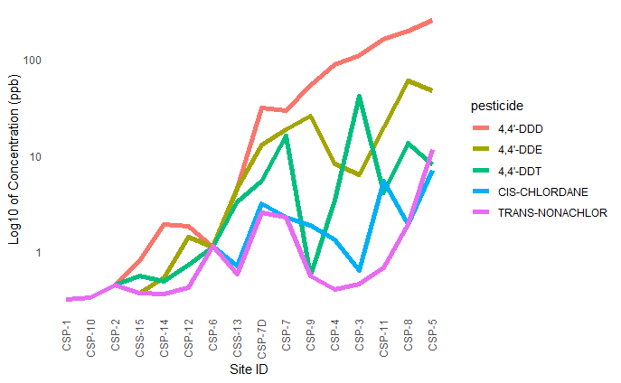

```r
tmp <- Pesticides.data
tmp$SAMPLE_ID <- reorder(tmp$SAMPLE_ID, tmp$totPesticides, mean, na.rm = TRUE)

tmp <- tmp %>% gather(key = 'pesticide', value = 'Concentration', 2:6) %>%
  mutate(pesticide = factor(pesticide)) %>%
  mutate(pesticide = reorder(pesticide, Concentration, function(x) -x[1]))


plt <- ggplot(tmp, aes(x=as.numeric(SAMPLE_ID), y = Concentration, color = pesticide)) +
  geom_line(lwd = 2) +
  scale_x_continuous(breaks = c(1:16-0.25), labels = levels(tmp$SAMPLE_ID), minor_breaks = FALSE) +
  #scale_color_discrete(labels = substr(levels(tmp$Pesticides), 0, gregexpr(pattern ='.,',levels(tmp$Pesticides) ) )) +
  xlab('Site ID') +
  ylab('Log10 of Concentration (ppb)') +
  scale_y_log10() +
  theme_minimal() +
  theme(axis.text.x = element_text(angle = 90, hjust = 1)) +
  theme(panel.grid = element_blank())
plt
```

##Sites by Pesticides

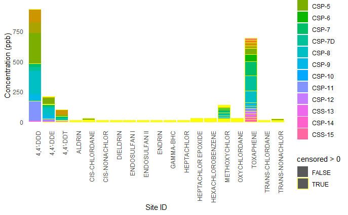

```r
plt <- ggplot(Pesticides.data.long, aes(PARAMETER_NAME, CONCENTRATION)) +
  geom_col(aes(fill = SAMPLE_ID, color = censored>0)) +
  scale_color_manual(values = c(NA, 'yellow')) +
  xlab('Site ID') +
  ylab('Concentration (ppb)') +
  theme_minimal() +
  theme(axis.text.x = element_text(angle = 90, hjust = 1)) +
  theme(panel.grid = element_blank())
plt
```

So, Pesticide data is dominated by the DDT residues. We probably only need to look at them. NOAA’s SQUIRTS include screening levels for the sum of hte three main DDT residues.

The SQUIRTS for the sum of the three DDT residues are as follows;

```r
type   <- c('TEL', 'ERL', 'PEL', 'ERM', 'AET')
levels <- c(3.89, 1.58,51.7, 46.1, 11)
```

Note that teh SQUIRTS have screening levels for “Chlordane” but not “cis-Chlordane”, and no screening values for Nonachlor.